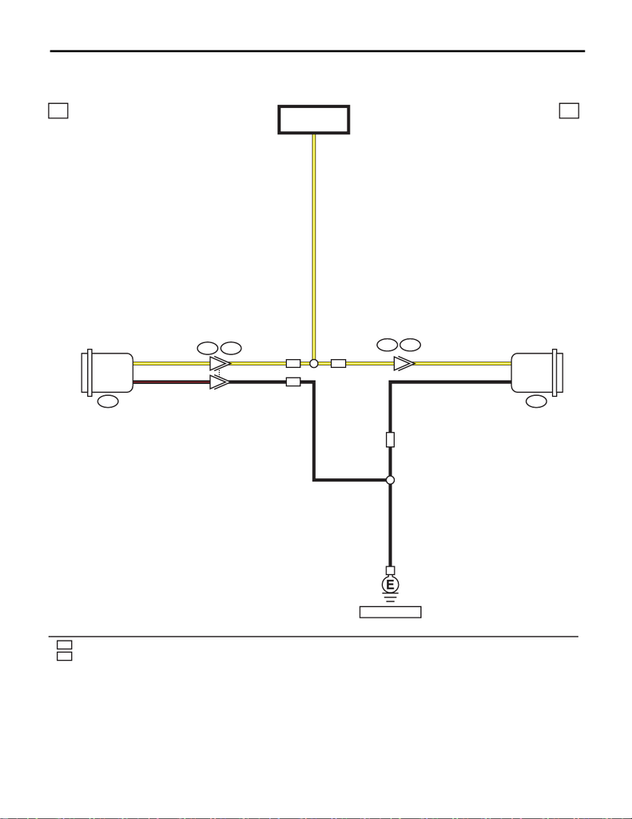

Rear Accessory Power Supply Socket System

WIRING SYSTEM

40.Rear Accessory Power Supply Socket System

A: WIRING DIAGRAM

WI-44536

11

a a

R81 R82

Y/W

Y/W2

B/R

Y/W

B1

AD9

Y/W 2

B1

R311

B

EJ FA

FA

EJ

14

13

AD6 R34

REAR ACCESSORY

POWER SUPPLY SOCKET

(CONSOLE)

REAR ACCESSORY

POWER SUPPLY SOCKET

(CONSOLE)

FB-21

F/B FUSE NO. 13

(ACC)

REF. TO GND [g]

FA

EJ

: ENGINE TYPE EJ

: ENGINE TYPE FA

[figure not shown]

Rear Accessory Power Supply Socket System

WIRING SYSTEM

AD9

1

2

WI-44537

b b

R311

1

2

(B)

R82

1

9

R34

123